# Exercise of Statistical Computing course

## Answer

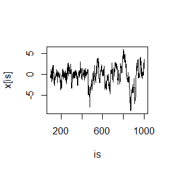

```r
set.seed(1)
n <- 1000 #Sample size
x <- numeric(n)
u <- runif(n)
theta=1
eta=0

x[1] <- rnorm(1)
k <- 0

# cauchy functions
f <- function(x, theta=1, eta=0){
  out <- 1/(pi * theta * (1+((x-eta)/theta)^2))
  return(out)
}

for(i in 2:n){
  xt <- x[i-1]
  y <- rnorm(1,mean=xt)
  R <- f(y)*dnorm(xt,mean=y)/(f(xt)*dnorm(y,mean=xt))
  if(u[i] <= R){
    x[i] <- y
  }else{
    x[i] <- xt
    k <- k+1
  }
}

is <- 101:n

plot(is,x[is],type="l")
```

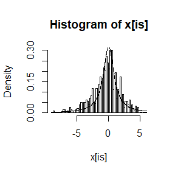

```r
hist(x[is], probability=TRUE,breaks=100)
plot.x <- seq(min(x[is]),max(x[is]),0.01)
lines(plot.x,f(plot.x))
```

```r
#compare the deciles
observations <- quantile(x[is],seq(0,1,0.1))
expectations <- qcauchy(seq(0,1,0.1))
decile <- data.frame(observations,expectations)
decile
```

```
##      observations expectations
## 0%     -8.8927769         -Inf
## 10%    -3.2422433   -3.0776835
## 20%    -1.8883217   -1.3763819
## 30%    -1.0868193   -0.7265425
## 40%    -0.5831603   -0.3249197
## 50%    -0.1373446    0.0000000
## 60%     0.2788956    0.3249197
## 70%     0.6170561    0.7265425
## 80%     1.2151632    1.3763819
## 90%     2.2273095    3.0776835
## 100%    5.9987643          Inf
```

We can see, the middle quantile is very close. The following QQ and histograms also verify this.

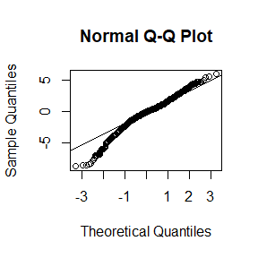

```r
qqnorm(x[is])
qqline(x[is])
```

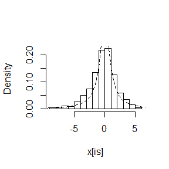

```r
sequence <- seq(0,1,0.01)
standardCauchy <- qcauchy(sequence)
standardCauchy <- standardCauchy[(standardCauchy> -Inf)
                                 & (standardCauchy< Inf)]
hist(x[is], freq = FALSE,main = "")
lines(standardCauchy, dcauchy(standardCauchy), lty = 2)
```

## Problem 9.6

Rao presented an example on genetic linkage of 197 animals in four categories (also discussed in [67, 106, 171, 266]). The group sizes are (125, 18, 20, 34). Assume that the probabilities of the corresponding multinomial distribution are
$$(\frac{1}{2}+\frac{\theta}{4},\frac{1-\theta}{4},\frac{1-\theta}{4},\frac{\theta}{4})$$
Estimate the posterior distribution of $\theta$ given the observed sample, using one of the methods in this chapter.

## Answer

Estimate the posterior distribution of $\theta$ given the observed sample is as follows.

```r
m <- 10000
burn.in <- 2000
sizes <- c(125,18,20,34)
size <- sum(sizes)

prob <- function(theta){
  p <- c(0.5+theta/4,(1-theta)/4,(1-theta)/4,theta/4)
}

prob.ratio <- function(n,d){
  prod(prob(n)^sizes/prob(d)^sizes)
}
```

I tried three different ways to produce samples.

```r
# random walk
# using unif(-0.25,0.25) as step

x.rw <- numeric(m)
k.rw <- 0
u <- runif(m)
v <- runif(m,-0.25,0.25)
x.rw[1] <- v[1]
for (i in 2:m){
  xt <- x.rw[i-1]
  y <- xt + v[i]
  r <- min(prob.ratio(y,xt),1)
  if(!is.nan(r) && u[i] <= r){
    x.rw[i] <- y
  }else{
    k.rw <- k.rw + 1
    x.rw[i] <- xt
  }
}
print(k.rw)
```

```
## [1] 6733
```

```r
# MH samplings
sd <- 0.5
min <- -0.8
max <- 0.8

rg <- function(p){
  return(runif(1,min-abs(p),max+abs(p)))
}

dg <- function(x,p){
  return(dunif(x,min-abs(p),max+abs(p)))
}

x.mh <- numeric(m)
k.mh <- 0
u <- runif(m)
x.mh[1] <- rg(0)
for(i in 2:m){
  xt <- x.mh[i-1]
  y <- rg(xt)
  r <- min(prob.ratio(y,xt)*dg(xt,y)/dg(y,xt),1)
  if(!is.na(r) && u[i] <= r){
    x.mh[i] <- y
  }else{
    x.mh[i] <- xt
    k.mh <- k.mh + 1
  }
}
print(k.mh)
```

```
## [1] 9810
```

```r
# independence sampler
x.i <- numeric(m)
k.i <- 0
x.i[i] <- rg(0)
u <- runif(m)
for(i in 2:m){
  xt <- x.i[i-1]
  y <- rg(0)
  r <- prob.ratio(y,xt)*dg(xt,0)/dg(y,0)
  if(u[i] <= r){
    x.i[i] <- y
  }else{
    x.i[i] <- xt
    k.i <- k.i + 1
  }
}
print(k.i)
```

```
## [1] 8973
```

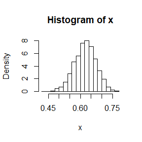

```r
#histogram
is <- (burn.in + 1):m
xs <- as.list(x.rw,x.mh)

x <- x.rw[is]
hist(x,probability=TRUE)
```

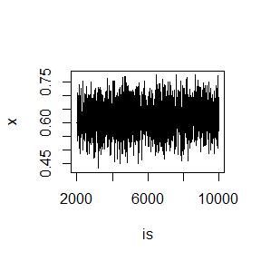

```r
plot(is,x,type="l")
```

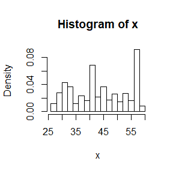

```r
x <- x.mh[is]
hist(x,probability=TRUE)
```

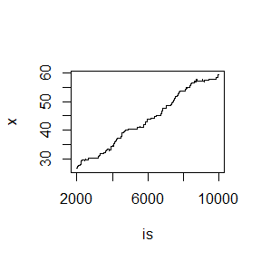

```r
plot(is,x,type="l")
```

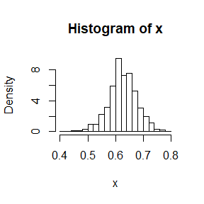

```r
x <- x.i[is]
hist(x,probability=TRUE)
```

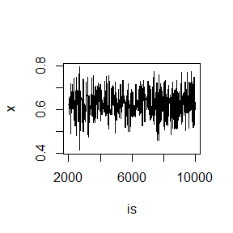

```r
plot(is,x,type="l")
```

```r
mu.rw <- mean(x.rw[is])
mu.mh <- mean(x.mh[is])
mu.i <- mean(x.i[is])
print(c(mu.rw,mu.mh,mu.i))
```

```
## [1]  0.6222162 43.8515593  0.6263975
```

We can see, the estimate of MH sampling with uniform prior distribution has big error while the random walk and independent prior distribution is good.

## Exercise 7 (20181123)

## Problem 9.6(continue)

For exercise 9.6, use the Gelman-Rubin method to monitor convergence of the chain, and run the chain until the chain has converged approximately to the target distribution according to $\hat{R}<1.2$.

## Answer

```r
Gelman.Rubin <- function(psi) {
  # psi[i,j] is the statistic psi(X[i,1:j])
  # for chain in i-th row of X
  psi <- as.matrix(psi)
  n <- ncol(psi)
  k <- nrow(psi)
  psi.means <- rowMeans(psi) #row means
  B <- n * var(psi.means) #between variance est.
  psi.w <- apply(psi, 1, "var") #within variances
  W <- mean(psi.w) #within est.
  v.hat <- W*(n-1)/n + (B/n) #upper variance est.
  r.hat <- v.hat / W #G-R statistic
  return(r.hat)
}

prob <- function(theta){
  p <- c(0.5+theta/4,(1-theta)/4,(1-theta)/4,theta/4)
}

prob.ratio <- function(n,d){
  prod(prob(n)^sizes/prob(d)^sizes)
}

sample.chain <- function(N, X1){
  #generates a Metropolis chain for multinomial distribution
  #in exercise 9.6 with random walk proposal distribution
  #and starting value X1
  x <- rep(0, N)
  x[1] <- X1
  u <- runif(N)
  v <- runif(N,-0.25,0.25)

  for (i in 2:N){
    xt <- x[i-1]
    y <- xt + v[i] #candidate point
    r <- min(prob.ratio(y,xt),1)
    if (!is.nan(r) && u[i] <= r){
      x[i] <- y
    }else{
      x[i] <- xt
    }
  }
  return(x)
}
```

The simulation is as follows:

```r
set.seed(1234)
k <- 4 #number of chains to generate
n <- 15000 #length of chains
b <- 1000 #burn-in length
sizes <- c(125,18,20,34)
size <- sum(sizes)
#choose overdispersed initial values
x0 <- c(0.2, 0.4, 0.6, 0.8)
#generate the chains
X <- matrix(0, nrow=k, ncol=n)
for (i in 1:k){
  X[i, ] <- sample.chain(n, x0[i])
}

#compute diagnostic statistics
psi <- t(apply(X, 1, cumsum))
for (i in 1:nrow(psi))
  psi[i,] <- psi[i,] / (1:ncol(psi))
print(Gelman.Rubin(psi))
```

```
## [1] 1.026943
```

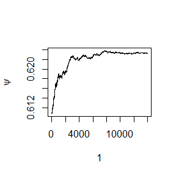

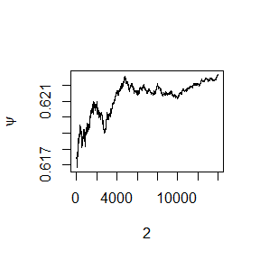

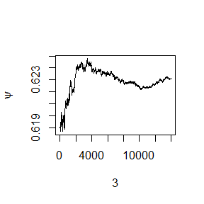

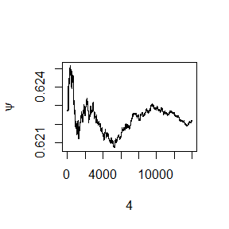

```r
#plot psi for the four chains

for (i in 1:k){
  plot(psi[i, (b+1):n], type="l", xlab=i, ylab=bquote(psi))
}
```

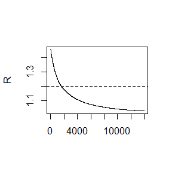

```r
#plot the sequence of R-hat statistics
rhat <- rep(0, n)
for (j in (b+1):n){
  rhat[j] <- Gelman.Rubin(psi[,1:j])
}
plot(rhat[(b+1):n], type="l", xlab="", ylab="R")
abline(h=1.2, lty=2)
```

It seems that the chain converge since N=1800.

## Problem 11.4

Find the intersection points $A(k)$ in $(0,\sqrt(k))$ of the curves
$$S_{k-1}(a)=P\left(t(k-1)>\sqrt{\frac{a^2(k-1)}{k-a^2}}\right)$$
and
$$S_k(a)=P\left(t(k)>\sqrt{\frac{a^2k}{k+1-a^2}}\right)$$
for $k = 4 : 25, 100, 500, 1000$, where t(k) is a Student t random variable with k degrees of freedom. (These intersection points determine the critical values for a t-test for scale-mixture errors proposed by Szekely [260].)

## Answer

```r
findIntersection <- function (k) {
  ##The function to find the intersection points
  s_k.minus.one <- function (a) {
    1-pt(sqrt(a^2*(k-1)/(k - a^2)), df=k-1)
  }

  s_k <- function (a) {
    1-pt(sqrt(a^2*k/(k+1-a^2)), df = k)
  }

  f <- function (a) {
    s_k(a) - s_k.minus.one(a)
  }

  eps = 1e-2
  return(uniroot(f, interval = c(eps, sqrt(k)-eps))$root)
}

rs = sapply(c(4:25, 100, 500, 1000), function (k) {
  findIntersection(k)
})
result <- data.frame(k=c(4:25, 100, 500, 1000),intersection=rs)
print(result)
```

```
##       k intersection
## 1     4     1.492073
## 2     5     1.533555
## 3     6     1.562745
## 4     7     1.584429
## 5     8     1.601184
## 6     9     1.614516
## 7    10     1.625389
## 8    11     1.634418
## 9    12     1.642026
## 10   13     1.648552
## 11   14     1.654175
## 12   15     1.659099
## 13   16     1.663454
## 14   17     1.667287
## 15   18     1.670733
## 16   19     1.673832
## 17   20     1.676605
## 18   21     1.679148
## 19   22     1.681468
## 20   23     4.785832
## 21   24     4.888979
## 22   25     4.990000
## 23  100     9.990000
## 24  500    22.350680
## 25 1000    31.612777
```

## Exercise 8 (20181130)

## Problem 11.6

Write a function to compute the cdf of the Cauchy distribution, which has density
$$\frac{1}{\theta\pi(1+[(x-\eta)/\theta]^2)},\ \ -\infty<x<\infty$$
where $\theta>0$. Compare your results to the results from the R function .(Also see the source code in .)

## Answer

```r
my.dcauchy <- function(x,eta,theta){
  stopifnot(theta > 0)
  return(1/(theta*pi*(1+((x-eta)/theta)^2)))
}

my.pcauchy <- function(x,eta,theta) {
  stopifnot(theta > 0)

  integral <- function (x) {
    my.dcauchy(x,eta,theta)
  }

  return(integrate(integral, lower = -Inf, upper = x)$value)
}

eta <- 0
theta <- 2
xs <- seq(-10, 10)
estimate <- sapply(xs, function(x) my.pcauchy(x, eta,theta))
truth <- sapply(xs, function(x) pcauchy(x, eta, theta))
round(rbind(estimate, truth), 4)
```

```
##            [,1]   [,2]  [,3]   [,4]   [,5]   [,6]   [,7]   [,8] [,9]
## estimate 0.0628 0.0696 0.078 0.0886 0.1024 0.1211 0.1476 0.1872 0.25
## truth    0.0628 0.0696 0.078 0.0886 0.1024 0.1211 0.1476 0.1872 0.25
##           [,10] [,11]  [,12] [,13]  [,14]  [,15]  [,16]  [,17]  [,18]
## estimate 0.3524   0.5 0.6476  0.75 0.8128 0.8524 0.8789 0.8976 0.9114
## truth    0.3524   0.5 0.6476  0.75 0.8128 0.8524 0.8789 0.8976 0.9114
##          [,19]  [,20]  [,21]
## estimate 0.922 0.9304 0.9372
## truth    0.922 0.9304 0.9372
```

## Problem 2(A-B-O blood type problem)

Let the three alleles be A, B and O.
$$\begin{array}{c|cccccc}
\hline
Genotype & \text{AA} & \text{BB} & \text{OO} & \text{AO} & \text{BO} & \text{AB} & \text{AA}\\
\hline
Frequency & \text{p2} & \text{q2} & \text{r2} & \text{2pr} & \text{2qr} & \text{2pq} & \text{1}\\
\hline
Count & \text{nAA} & \text{nBB} & \text{nOO} & \text{nAO} & \text{nBO} & \text{nAB} & \text{n}\\
\hline
\end{array}$$

1. Observed data: $n_{A??} = n_{AA} + n_{AO} = 28 (A-type)$, $n_{B??} = n_{BB} + n_{BO} = 24 (B-type)$, $n_{OO} = 41 (O-type), n_{AB} = 70(AB-type)$.
2. Use EM algorithm to solve MLE of p and q (consider missing data $n_{AA}$ and $n_{BB}$).
3. Record the maximum likelihood values in M-steps, are they increasing?

## Answer

1. The EM algorithm is as follows:

```r
counts <- c(28,24,41,70)#nA,nB,nO,nAB
theta.init <- c(0.2,0.2,0.6)#intial value:p,q,r

sample.size = sum(counts)

n.A = counts[1]
n.B = counts[2]
n.O = counts[3]
n.AB = counts[4]

##EM algorithm
theta.cur = theta.init
theta.next = theta.cur
log.L <- vector(mode="numeric",length=0)

discrepancy = 1.0
i <- 1

while(discrepancy>10^-7){
  theta.cur = theta.next

  ## E step
  n.aa = n.A*theta.cur[1]^2/(theta.cur[1]^2+2*theta.cur[1]*theta.cur[3])
  n.ao = n.A*2*theta.cur[1]*theta.cur[3]/(theta.cur[1]^2+2*theta.cur[1]*theta.cur[3])
  n.bb = n.B*theta.cur[2]^2/(theta.cur[2]^2+2*theta.cur[2]*theta.cur[3])
  n.bo = n.B*2*theta.cur[2]*theta.cur[3]/(theta.cur[2]^2+2*theta.cur[2]*theta.cur[3])
  n.oo = n.O
  n.ab = n.AB

  ## M step
  theta.next[1] = (2*n.aa+n.ab+n.ao)/(2*sample.size)
  theta.next[2] = (2*n.bb+n.ab+n.bo)/(2*sample.size)
  theta.next[3] = (2*n.oo+n.ao+n.bo)/(2*sample.size)
  logL  <- n.A*log((theta.next[1]^2+2*theta.next[1]*theta.next[3]))+
    n.B*log((theta.next[1]^2+2*theta.next[1]*theta.next[3]))+
    n.O*log((theta.next[3]^2))+
    n.AB*log((theta.next[2]^2+2*theta.next[2]*theta.next[3]))
  log.L[i] <- logL
  i <- i+1
  print(c(theta.next,logL))

  discrepancy = max(abs(theta.next - theta.cur))
}
```

```
## [1]    0.3128834    0.2988606    0.3882559 -213.0048770
## [1]    0.3252817    0.3088035    0.3659148 -217.4157752
## [1]    0.3270424    0.3101899    0.3627677 -218.0842039
## [1]    0.3272999    0.3103919    0.3623081 -218.1828162
## [1]    0.3273377    0.3104216    0.3622407 -218.1973131
## [1]    0.3273433    0.3104259    0.3622308 -218.1994432
## [1]    0.3273441    0.3104266    0.3622293 -218.1997561
## [1]    0.3273442    0.3104267    0.3622291 -218.1998021
## [1]    0.3273442    0.3104267    0.3622291 -218.1998088
```

The value of p and q solved by our EM algorithm are $p=0.3273442$ and $q=0.3104267$.

(2)It’s obvious that the maximum likelihood values in M-steps is decreasing.

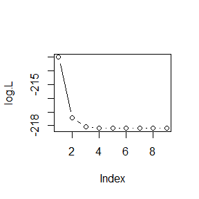

```r
plot(log.L,type="b",lty=1)
```

## Exercise 9 (20181207)

## Problem 1(Exercise 3, p204, Advanced R)

Use both for loops and to fit linear models to the using the formulas stored in this list:

```r
formulas <- list(
  mpg ~ disp,
  mpg ~ I(1 / disp),
  mpg ~ disp + wt,
  mpg ~ I(1 / disp) + wt
)
```

## Answer

(1)Using loops:

```r
# for loop
lf1 <- vector("list", length(formulas))
for (i in seq_along(formulas)){
  lf1[[i]] <- lm(formulas[[i]], data = mtcars)
}
lf1
```

```
## [[1]]
##
## Call:
## lm(formula = formulas[[i]], data = mtcars)
##
## Coefficients:
## (Intercept)         disp
##    29.59985     -0.04122
##
##
## [[2]]
##
## Call:
## lm(formula = formulas[[i]], data = mtcars)
##
## Coefficients:
## (Intercept)    I(1/disp)
##       10.75      1557.67
##
##
## [[3]]
##
## Call:
## lm(formula = formulas[[i]], data = mtcars)
##
## Coefficients:
## (Intercept)         disp           wt
##    34.96055     -0.01772     -3.35083
##
##
## [[4]]
##
## Call:
## lm(formula = formulas[[i]], data = mtcars)
##
## Coefficients:
## (Intercept)    I(1/disp)           wt
##      19.024     1142.560       -1.798
```

(2)Using :

```r
# lapply (2 versions)
la1 <- lapply(formulas, lm, data = mtcars)
la2 <- lapply(formulas, function(x) lm(formula = x, data = mtcars))
la1
```

```
## [[1]]
##
## Call:
## FUN(formula = X[[i]], data = ..1)
##
## Coefficients:
## (Intercept)         disp
##    29.59985     -0.04122
##
##
## [[2]]
##
## Call:
## FUN(formula = X[[i]], data = ..1)
##
## Coefficients:
## (Intercept)    I(1/disp)
##       10.75      1557.67
##
##
## [[3]]
##
## Call:
## FUN(formula = X[[i]], data = ..1)
##
## Coefficients:
## (Intercept)         disp           wt
##    34.96055     -0.01772     -3.35083
##
##
## [[4]]
##
## Call:
## FUN(formula = X[[i]], data = ..1)
##
## Coefficients:
## (Intercept)    I(1/disp)           wt
##      19.024     1142.560       -1.798
```

```r
la2
```

```
## [[1]]
##
## Call:
## lm(formula = x, data = mtcars)
##
## Coefficients:
## (Intercept)         disp
##    29.59985     -0.04122
##
##
## [[2]]
##
## Call:
## lm(formula = x, data = mtcars)
##
## Coefficients:
## (Intercept)    I(1/disp)
##       10.75      1557.67
##
##
## [[3]]
##
## Call:
## lm(formula = x, data = mtcars)
##
## Coefficients:
## (Intercept)         disp           wt
##    34.96055     -0.01772     -3.35083
##
##
## [[4]]
##
## Call:
## lm(formula = x, data = mtcars)
##
## Coefficients:
## (Intercept)    I(1/disp)           wt
##      19.024     1142.560       -1.798
```

Obviously, two results are same.

## Problem 2(Exercise 4, p204, Advanced R)

Fit the model to each of the bootstrap replicates of in the list below by using a for loop and . Can you do it without an anonymous function?

```r
bootstraps <- lapply(1:10, function(i){
  rows <- sample(1:nrow(mtcars), rep = TRUE)
  mtcars[rows, ]
})#eturns a list of the same length as mtcars
```

## Answer

```r
## for loop
lf <- vector("list", length(bootstraps))
for (i in seq_along(bootstraps)){
  lf[[i]] <- lm(mpg ~ disp, data = bootstraps[[i]])
}
lf
```

```
## [[1]]
##
## Call:
## lm(formula = mpg ~ disp, data = bootstraps[[i]])
##
## Coefficients:
## (Intercept)         disp
##    31.03393     -0.04712
##
##
## [[2]]
##
## Call:
## lm(formula = mpg ~ disp, data = bootstraps[[i]])
##
## Coefficients:
## (Intercept)         disp
##    31.74721     -0.05465
##
##
## [[3]]
##
## Call:
## lm(formula = mpg ~ disp, data = bootstraps[[i]])
##
## Coefficients:
## (Intercept)         disp
##    31.54409     -0.04672
##
##
## [[4]]
##
## Call:
## lm(formula = mpg ~ disp, data = bootstraps[[i]])
##
## Coefficients:
## (Intercept)         disp
##    29.34256     -0.03967
##
##
```

[output cut: 43 more lines]

```
## lm(formula = mpg ~ disp, data = bootstraps[[i]])
##
## Coefficients:
## (Intercept)         disp
##    31.07670     -0.04553
##
##
## [[10]]
##
## Call:
## lm(formula = mpg ~ disp, data = bootstraps[[i]])
##
## Coefficients:
## (Intercept)         disp
##    27.37863     -0.03694
```

```r
# lapply without anonymous function
la <- lapply(bootstraps, lm, formula = mpg ~ disp)
la
```

```
## [[1]]
##
## Call:
## FUN(formula = ..1, data = X[[i]])
##
## Coefficients:
## (Intercept)         disp
##    31.03393     -0.04712
##
##
## [[2]]
##
## Call:
## FUN(formula = ..1, data = X[[i]])
##
## Coefficients:
## (Intercept)         disp
##    31.74721     -0.05465
##
##
## [[3]]
##
## Call:
## FUN(formula = ..1, data = X[[i]])
##
## Coefficients:
## (Intercept)         disp
##    31.54409     -0.04672
##
##
## [[4]]
##
## Call:
## FUN(formula = ..1, data = X[[i]])
##
## Coefficients:
## (Intercept)         disp
##    29.34256     -0.03967
##
##
```

[output cut: 43 more lines]

```
## FUN(formula = ..1, data = X[[i]])
##
## Coefficients:
## (Intercept)         disp
##    31.07670     -0.04553
##
##
## [[10]]
##
## Call:
## FUN(formula = ..1, data = X[[i]])
##
## Coefficients:
## (Intercept)         disp
##    27.37863     -0.03694
```

## Problem 3(Exercise 5, p204, Advanced R)

For each model in the previous two exercises, extract $\mathbf{R^2}$ using the function below.

```r
rsq <- function(mod) summary(mod)$r.squared
```

## Answer

For the models in exercise 1:

```r
sapply(la1, rsq)
```

```
## [1] 0.7183433 0.8596865 0.7809306 0.8838038
```

```r
sapply(la2, rsq)
```

```
## [1] 0.7183433 0.8596865 0.7809306 0.8838038
```

```r
sapply(lf1, rsq)
```

```
## [1] 0.7183433 0.8596865 0.7809306 0.8838038
```

For the models in exercise 2:

```r
sapply(la, rsq)
```

```
##  [1] 0.6561281 0.7824734 0.7599183 0.7114511 0.6310431 0.7805282 0.8347510
##  [8] 0.6274358 0.7247127 0.7948518
```

```r
sapply(lf, rsq)
```

```
##  [1] 0.6561281 0.7824734 0.7599183 0.7114511 0.6310431 0.7805282 0.8347510
##  [8] 0.6274358 0.7247127 0.7948518
```

## Problem 4(Exercise 3, p214, Advanced R)

The following code simulates the performance of a t-test for non-normal data. Use and an anonymous function to extract the p-value from every trial.

```r
trials <- replicate(100,t.test(rpois(10, 10), rpois(7, 10)),
                    simplify = FALSE)
```

Extra challenge: get rid of the anonymous function by using [[ directly.

## Answer

```r
# anonymous function:
sapply(trials, function(test) test$p.value)
```

```
##   [1] 0.226234733 0.878699690 0.023636944 0.002863181 0.283263429
##   [6] 0.342715493 0.280393022 0.895401464 0.444668045 0.955958794
##  [11] 0.840814492 0.915422519 0.318264061 0.659470388 0.755335363
##  [16] 0.062552306 0.201374001 0.843761138 0.102700821 0.810551787
##  [21] 0.336871352 0.983426627 0.654647238 0.212360540 0.558590192
##  [26] 0.515757542 0.627910997 0.354903758 0.932726022 0.410597054
##  [31] 0.588269425 0.766716658 0.305949455 0.191648159 0.923430953
##  [36] 0.233832635 0.007715163 0.636923221 0.546470935 0.101839183
##  [41] 0.633595727 0.885810579 0.641792946 0.260437129 0.377980255
##  [46] 0.329324914 0.909868603 0.904938123 0.895475321 0.796516410
##  [51] 0.886190335 0.241623031 0.457651060 0.508391008 0.554745562
##  [56] 0.555530013 0.517136450 0.237152954 0.726398646 0.128271193
##  [61] 0.055546426 0.833201948 0.055684921 0.313481890 0.674045813
##  [66] 0.496379419 0.181788795 0.588977335 0.272538493 0.428096391
##  [71] 0.690500493 0.147715047 0.120305341 0.465157841 0.805365236
##  [76] 0.548290932 0.279067560 0.920286134 0.298992191 0.283991735
##  [81] 0.441317646 0.533652819 0.142944393 0.920812613 0.634335308
##  [86] 0.719262180 0.343715387 0.506414946 0.647267652 0.161587341
##  [91] 0.558221586 0.571337643 0.948372532 0.481177694 0.846617931
##  [96] 0.537704063 0.642115127 0.139222858 0.436743209 0.462786126
```

```r
sapply(trials, '[[', i = "p.value")
```

```
##   [1] 0.226234733 0.878699690 0.023636944 0.002863181 0.283263429
##   [6] 0.342715493 0.280393022 0.895401464 0.444668045 0.955958794
##  [11] 0.840814492 0.915422519 0.318264061 0.659470388 0.755335363
##  [16] 0.062552306 0.201374001 0.843761138 0.102700821 0.810551787
##  [21] 0.336871352 0.983426627 0.654647238 0.212360540 0.558590192
##  [26] 0.515757542 0.627910997 0.354903758 0.932726022 0.410597054
##  [31] 0.588269425 0.766716658 0.305949455 0.191648159 0.923430953
##  [36] 0.233832635 0.007715163 0.636923221 0.546470935 0.101839183
##  [41] 0.633595727 0.885810579 0.641792946 0.260437129 0.377980255
##  [46] 0.329324914 0.909868603 0.904938123 0.895475321 0.796516410
##  [51] 0.886190335 0.241623031 0.457651060 0.508391008 0.554745562
##  [56] 0.555530013 0.517136450 0.237152954 0.726398646 0.128271193
##  [61] 0.055546426 0.833201948 0.055684921 0.313481890 0.674045813
##  [66] 0.496379419 0.181788795 0.588977335 0.272538493 0.428096391
##  [71] 0.690500493 0.147715047 0.120305341 0.465157841 0.805365236
##  [76] 0.548290932 0.279067560 0.920286134 0.298992191 0.283991735
##  [81] 0.441317646 0.533652819 0.142944393 0.920812613 0.634335308
##  [86] 0.719262180 0.343715387 0.506414946 0.647267652 0.161587341
##  [91] 0.558221586 0.571337643 0.948372532 0.481177694 0.846617931
##  [96] 0.537704063 0.642115127 0.139222858 0.436743209 0.462786126
```

## Problem 5(Exercise 6, p214, Advanced R)

Implement a combination of and to create an variant that iterates in parallel over all of its inputs and stores its outputs in a vector (or a matrix). What arguments should the function take?

## Answer

This exercise is about working with a list of lists, like in the following example:

```r
library(parallel)
testlist <- list(iris, mtcars, cars)
lapply(testlist, function(x) vapply(x, mean, numeric(1)))
```

```
## [[1]]
## Sepal.Length  Sepal.Width Petal.Length  Petal.Width      Species
##     5.843333     3.057333     3.758000     1.199333           NA
##
## [[2]]
##        mpg        cyl       disp         hp       drat         wt
##  20.090625   6.187500 230.721875 146.687500   3.596563   3.217250
##       qsec         vs         am       gear       carb
##  17.848750   0.437500   0.406250   3.687500   2.812500
##
## [[3]]
## speed  dist
## 15.40 42.98
```

So we can get the same result with a more specialized function:

```r
lmapply <- function(X, FUN, FUN.VALUE, simplify = FALSE){
  out <- Map(function(x) vapply(x, FUN, FUN.VALUE), X)
  if(simplify == TRUE){return(simplify2array(out))}
  out
}
lmapply(testlist, mean, numeric(1))
```

```
## [[1]]
## Sepal.Length  Sepal.Width Petal.Length  Petal.Width      Species
##     5.843333     3.057333     3.758000     1.199333           NA
##
## [[2]]
##        mpg        cyl       disp         hp       drat         wt
##  20.090625   6.187500 230.721875 146.687500   3.596563   3.217250
##       qsec         vs         am       gear       carb
##  17.848750   0.437500   0.406250   3.687500   2.812500
##
## [[3]]
## speed  dist
## 15.40 42.98
```

## Exercise 10 (20181214)

## Problem 1

Make a faster version of $\textbf{chisq.test()}$ that only computes the chi-square test statistic when the input is two numeric vectors with no missing values. You can try simplifying $\textbf{chisq.test()}$ or by coding from the mathematical definition.

## Answer

Since $\textbf{chisq.test()}$ has a long code, we try a shorter one:

```r
chisq.test2 <- function(x, y){

  # Input
  if (!is.numeric(x)) {
    stop("x must be numeric")}
  if (!is.numeric(y)) {
    stop("y must be numeric")}
  if (length(x) != length(y)) {
    stop("x and y must have the same length")}
  if (length(x) <= 1) {
    stop("length of x must be greater one")}
  if (any(c(x, y) < 0)) {
    stop("all entries of x and y must be greater or equal zero")}
  if (sum(complete.cases(x, y)) != length(x)) {
    stop("there must be no missing values in x and y")}
  if (any(is.null(c(x, y)))) {
    stop("entries of x and y must not be NULL")}

  # compute the theoretical value
  m <- rbind(x, y)#the actual value
  margin1 <- rowSums(m)
  margin2 <- colSums(m)
  n <- sum(m)
  me <- tcrossprod(margin1, margin2) / n #the theoretical value

  # Output
  STATISTIC = sum((m - me)^2 / me)
  dof <- (length(margin1) - 1) * (length(margin2) - 1)#degree of freedom
  p <- pchisq(STATISTIC, df = dof, lower.tail = FALSE)
  return(list(X_squared = STATISTIC, df = dof, `p-value` = p))
}
```

Then check if $\textbf{chisq.text2()}$ returns the same results:

```r
a <- 11:15
b <- c(11,12.5,13.5,14.5,15.5)
m_test <- cbind(a,b)

identical(chisq.test(m_test),chisq.test2(a, b))
```

```
## [1] FALSE
```

The results are not same.

```r
chisq.test(m_test)
```

```
##
##  Pearson's Chi-squared test
##
## data:  m_test
## X-squared = 0.0063051, df = 4, p-value = 1
```

```r
chisq.test2(a, b)
```

```
## $X_squared
## [1] 0.006305112
##
## $df
## [1] 4
##
## $`p-value`
## [1] 0.999995
```

By observing the results, we find that there is a slight difference in p value.

Finally compare the run time:

```r
chisq.test2c <- compiler::cmpfun(chisq.test2)

microbenchmark::microbenchmark(
  chisq.test(m_test),
  chisq.test2(a,b),
  chisq.test2c(a,b)
)
```

```
## Unit: microseconds
##                expr    min      lq      mean median       uq      max
##  chisq.test(m_test) 71.254 75.5205 290.07856 82.561 183.6805 9960.961
##   chisq.test2(a, b) 19.627 20.9075  55.71470 24.320  35.8405 1387.521
##  chisq.test2c(a, b) 19.627 20.9070  33.53235 23.894  34.1340  163.414
##  neval
##    100
##    100
##    100
```

## Problem 2

Can you make a faster version of for the case of an input of two integer vectors with no missing values? Can you use it to speed up your chi-square test?

## Answer

```r
table2 <- function(x,y){

  x_val <- unique(x)
  y_val <- unique(y)
  mat <- matrix(0L, length(x_val), length(y_val))
  for (i in seq_along(x)) {
    mat[which(x_val == x[[i]]), which(y_val == y[[i]])] <-
      mat[which(x_val == x[[i]]),  which(y_val == y[[i]])] + 1L
  }
  dimnames <- list(x_val, y_val)
  names(dimnames) <- as.character(as.list(match.call())[-1])  # R has names for dimnames... :/
  tab <- array(mat, dim = dim(mat), dimnames = dimnames)
  class(tab) <- "table"
  tab
}
```

Then check if $\textbf{table2()}$ returns the same results:

```r
x <- c(1, 2, 3, 1, 2, 3)
y <- c(2, 3, 4, 2, 3, 4)
identical(table(x,y), table2(x,y))
```

```
## [1] TRUE
```

Finally compare the run time:

```r
microbenchmark::microbenchmark(table(x,y), table2(x,y))
```

```
## Unit: microseconds
##          expr     min       lq     mean  median       uq      max neval
##   table(x, y) 279.894 351.5740 431.8983 361.814 391.4675 1707.520   100
##  table2(x, y) 112.640 118.6145 152.6578 128.428 138.4545  767.574   100
```